# Case Study 02

Rajesh Satluri

4/1/2020

#Description DDSAnalytics is an analytics company that specializes in talent management solutions for Fortune 100 companies. Talent management is defined as the iterative process of developing and retaining employees. It may include workforce planning, employee training programs, identifying high-potential employees and reducing/preventing voluntary employee turnover (attrition). To gain a competitive edge over its competition, DDSAnalytics is planning to leverage data science for talent management. The executive leadership has identified predicting employee turnover as its first application of data science for talent management. Before the business green lights the project, they have tasked your data science team to conduct an analysis of existing employee data.

You have been given a dataset (CaseStudy2-data.csv) to do a data analysis to identify factors that lead to attrition. You should identify the top three factors that contribute to turnover (backed up by evidence provided by analysis). There may or may not be a need to create derived attributes/variables/features. The business is also interested in learning about any job role specific trends that may exist in the data set (e.g., “Data Scientists have the highest job satisfaction”). You can also provide any other interesting trends and observations from your analysis. The analysis should be backed up by robust experimentation and appropriate visualization. Experiments and analysis must be conducted in R. You will also be asked to build a model to predict attrition. Details are below.

#Deliverables

This is an individual project. You all are a tight cohort which is so valuable; I want to harness the power that that represents while maintaining the individual-ness of the project. The general rules (dos and don’ts) that each student will be on their honor to abide by are: Dos: 1. Do get excited about the project! 2. Do do all the coding. 3. Do discuss specific questions with your peers … i.e. if you want to add a heatmap but don’t know how to code it … you may ask a peer to show you how they did theirs or ask them to point you to a good resource. You are encouraged to ask me as well. However, be sure to recognize the Don’ts below! Don’ts: 1. Don’t ever email/give your code / write up / materials related to your approach to the problem or presentation to any student in the class. 2. Don’t code anything for anyone else.

In general, when deciding between two courses of action, if it feels like it is in the grey area, it is probably in the “Don’t” column. If you feel like you need clarity or a ruling on something you are not sure is appropriate, just shoot me an email.

#UNIT 14 and 15 Live Sessions: The due date for videoed submission is Saturday, Dec 5th at 11:59pm (Week 15). We will not meet for Live Session 15 and there will not be a live presentation component … use this time finish up your project. You know what I am looking for now and in reality, you will only get one shot at a great presentation. With that said, I will be available to meet during the Live Session Time for optional / voluntary meetings… I will have sign up times on the wall as usual. Make it a great recording and end the semester with a fantastic presentation / analysis!

However, we will meet for Live Session 14. Live Session 14 will be for any Data Science News of the Weeks that needs to be completed and I will answer any questions about the projects that develop by that time (asked via the Wall.) With that said, our Unit 14 class is currently on Thanksgiving so I will need to reschedule that one. I will hold that class on Sunday evening Dec 1 at 7pm. Please try and make the class but if you cannot, it is required to watch the video.

#Further Details: Similar to Case Study 1, you will need to record and upload to YouTube a 7-minute presentation. To do this you can download Jing which is a free video software available at https://www.techsmith.com/jing-tool.html or use your preferred screen capture software. You can assume that your audience is the CEO and CFO of Frito Lay (your client). It is a diverse audience; the CEO is a statistician and the CFO has had only one class in statistics. They have indicated that you cannot take more than 7 minutes of their time. 30% of your grade will be based on the presentation. The goal is to communicate the findings of the project in a clear, concise and scientific manner. Finally, include the link in your RMarkdown file. Finally, finally make sure to put the link to the YouTube video in the Google Doc. The links will be available for a week at which time you may take your video off of YouTube if you wish. Please make sure and check out at least 3 of your peer’s presentations!

I provided an additional data set of 300 observations that do not have the labels (attrition or not attrition). We will refer to this data set as the “Competition Set” and is in the file “CaseStudy2CompSet No Attrition.csv”. I have the real labels and will thus assess the accuracy rate of your best classification model. 10% of your grade will depend on the sensitivity and specificity rate of your “best” classification model for identifying attrition. You must provide a model that will attain at least 60% sensitivity and specificity (60 each = 120 total) for the training and the validation set. Therefore, you must provide the labels (ordered by ID) in a csv file. Please include this in your GitHub repository and call the file “Case2PredictionsXXXX Attrition.csv”. XXXX is your last name. (Example: Case2PredictionsSadler Attrition.csv” would be mine.) An example submission file can be found on GitHub: Case2PredictionsClassifyEXAMPLE.csv.

I have also provided an additional data set of 300 observations that do not have the Monthly Incomes. This data is in the file “CaseStudy2CompSet No Salary.csv”. I have the real monthly incomes (salaries) and will thus assess the RMSE regression model. 10% of your grade will depend on the RMSE (Root Mean square error) of your final model. You must provide a model that will attain a RMSE < $3000 for the training and the validation set. Therefore, you must provide the predicted salaries (ordered by ID) in a csv file. Please include this in your GitHub repository and call the file “Case2PredictionsXXXX Salary.csv”. XXXX is your last name. (Example: Case2PredictionsSadler Salary.csv” would be mine.) An example submission file can be found on GitHub: Case2PredictionsRegressEXAMPLE.csv.

Notes on models to fit: IMPORTANT: First and foremost, you may use outside models that we have not covered but it must be in addition to models that we have covered in class. This means for classifying attrition, you must use either k-NN or naive Bayes but may also use other models (logistic regression, random forest, LDA, SVM, etc) as long as you compare the results between the two or more models. You may then use any of the models to fulfill the 60/60 sensitivity/specificity requirement. This goes for regression as well; you must use linear regression but may include additional models for comparison and use in the competition (LASSO, random forest, ensemble models, etc.).

Create a GitHub repository named CaseStudy2DDS with an RMarkdown file containing an executive summary, introduction to the project, all supporting code and analysis, and the slides for the presentation. The repository should also include your prediction csv file and don’t forget to put the link to the YouTube video in the RMarkdown file. Submit a link to the GitHub repository via the space provided for the Case Study 02 page in 2DS. Finally, make sure put the link to the YouTube video on the Google Doc.

Finally, create a Knit file out of your RMD and display it on your GitHub Site you created in Unit 12. Include the link to your Youtube video (and a link to your RShiny app too if there is one!)

#Bonus: Up to 3 points: Create an RShiny App to help visualize you results. The amount of bonus points awarded will be based on correctness, creativeness, effectiveness of the visualization / app.

#BONUS:

The data scientist with the highest sensitivity + specificity (both at least 60%) on the classification validation set will win the Bonus: 5 extra points and bragging rights! This bonus is between all 4 sections. 1 prize between all 40+ students.

The data scientist with the lowest RMSE on the regression validation set will win the Bonus: 5 extra points and bragging rights! This bonus is between all 4 sections. 1 prize between all 40+ students.

## Load Libraries

```r
#install.packages("vctrs")
library(vctrs)
library(qwraps2)
```

```r
library(tidyverse) # super library that loads dplyr, ggplot2, lubridate, tidyr, stringr, etc.
library(DataExplorer) # shows missing values by bar and percentage.
library(maps) # used for heat map
library(openintro) # used to convert state abbreviation to full state name
library(gdata)
library(mapdata)
library(mime)
library(treemap) # used for displaying hierarchical data as a set of nested rectangles
library(VIM)
library(inspectdf) #usd for columnwise summary, comparison and visualisation of data frames
library(GGally) # used for ggpairs ()to plot multiple variables, combines different plots into matrix
library(ggthemes)# used for adding some extra themes, geoms, and scales for 'ggplot2
library(gridExtra)
library(class)
library(broom)
library(caret)
library(MASS)
library(car)
library(cowplot)
library(corrplot)
library(leaps)
library(e1071)
library(data.table)
library(dplyr)
theme_set(theme_classic())
```

## Load Data

```r
tm_emp_data = read.csv("https://raw.githubusercontent.com/rajeshsk/DDS-Project-Two/master/Data/CaseStudy2-data.csv", sep = ",", header = TRUE)
#tm_emp_data = read.csv(file.choose(),header = TRUE, sep = ',')
```

## Inspect the data

```r
names(tm_emp_data) # view the variable names
```

```
##  [1] "ID"                       "Age"
##  [3] "Attrition"                "BusinessTravel"
##  [5] "DailyRate"                "Department"
##  [7] "DistanceFromHome"         "Education"
##  [9] "EducationField"           "EmployeeCount"
## [11] "EmployeeNumber"           "EnvironmentSatisfaction"
## [13] "Gender"                   "HourlyRate"
## [15] "JobInvolvement"           "JobLevel"
## [17] "JobRole"                  "JobSatisfaction"
## [19] "MaritalStatus"            "MonthlyIncome"
## [21] "MonthlyRate"              "NumCompaniesWorked"
## [23] "Over18"                   "OverTime"
## [25] "PercentSalaryHike"        "PerformanceRating"
## [27] "RelationshipSatisfaction" "StandardHours"
## [29] "StockOptionLevel"         "TotalWorkingYears"
## [31] "TrainingTimesLastYear"    "WorkLifeBalance"
## [33] "YearsAtCompany"           "YearsInCurrentRole"
## [35] "YearsSinceLastPromotion"  "YearsWithCurrManager"
```

```r
dim(tm_emp_data) # view the dimensions of the data
```

```
## [1] 870  36
```

```r
str(tm_emp_data) # view the structure of the data
```

```
## 'data.frame':    870 obs. of  36 variables:
##  $ ID                      : int  1 2 3 4 5 6 7 8 9 10 ...
##  $ Age                     : int  32 40 35 32 24 27 41 37 34 34 ...
##  $ Attrition               : Factor w/ 2 levels "No","Yes": 1 1 1 1 1 1 1 1 1 1 ...
##  $ BusinessTravel          : Factor w/ 3 levels "Non-Travel","Travel_Frequently",..: 3 3 2 3 2 2 3 3 3 2 ...
##  $ DailyRate               : int  117 1308 200 801 567 294 1283 309 1333 653 ...
##  $ Department              : Factor w/ 3 levels "Human Resources",..: 3 2 2 3 2 2 2 3 3 2 ...
##  $ DistanceFromHome        : int  13 14 18 1 2 10 5 10 10 10 ...
##  $ Education               : int  4 3 2 4 1 2 5 4 4 4 ...
##  $ EducationField          : Factor w/ 6 levels "Human Resources",..: 2 4 2 3 6 2 4 2 2 6 ...
##  $ EmployeeCount           : int  1 1 1 1 1 1 1 1 1 1 ...
##  $ EmployeeNumber          : int  859 1128 1412 2016 1646 733 1448 1105 1055 1597 ...
##  $ EnvironmentSatisfaction : int  2 3 3 3 1 4 2 4 3 4 ...
##  $ Gender                  : Factor w/ 2 levels "Female","Male": 2 2 2 1 1 2 2 1 1 2 ...
##  $ HourlyRate              : int  73 44 60 48 32 32 90 88 87 92 ...
```

[output cut: 22 more lines]

```r
head(tm_emp_data, n = 5) # view the first 5 records
```

```
##   ID Age Attrition    BusinessTravel DailyRate             Department
## 1  1  32        No     Travel_Rarely       117                  Sales
## 2  2  40        No     Travel_Rarely      1308 Research & Development
## 3  3  35        No Travel_Frequently       200 Research & Development
## 4  4  32        No     Travel_Rarely       801                  Sales
## 5  5  24        No Travel_Frequently       567 Research & Development
##   DistanceFromHome Education   EducationField EmployeeCount EmployeeNumber
## 1               13         4    Life Sciences             1            859
## 2               14         3          Medical             1           1128
## 3               18         2    Life Sciences             1           1412
## 4                1         4        Marketing             1           2016
## 5                2         1 Technical Degree             1           1646
##   EnvironmentSatisfaction Gender HourlyRate JobInvolvement JobLevel
## 1                       2   Male         73              3        2
## 2                       3   Male         44              2        5
```

[output cut: 33 more lines]

```r
tail(tm_emp_data, n = 5) # view the last 5 records
```

```
##      ID Age Attrition    BusinessTravel DailyRate             Department
## 866 866  48        No     Travel_Rarely       855 Research & Development
## 867 867  32        No        Non-Travel       976                  Sales
## 868 868  47        No     Travel_Rarely       571                  Sales
## 869 869  45        No     Travel_Rarely      1457 Research & Development
## 870 870  35        No Travel_Frequently       138 Research & Development
##     DistanceFromHome Education EducationField EmployeeCount EmployeeNumber
## 866                4         3  Life Sciences             1           1363
## 867               26         4      Marketing             1            333
## 868               14         3        Medical             1           1503
## 869                7         3        Medical             1           1195
## 870                2         3        Medical             1            269
##     EnvironmentSatisfaction Gender HourlyRate JobInvolvement JobLevel
## 866                       4   Male         54              3        3
## 867                       3   Male        100              3        2
```

[output cut: 33 more lines]

```r
summary(tm_emp_data) # view basic model data i.e. min, max, mdedium, mean, etc.
```

```
##        ID             Age        Attrition           BusinessTravel
##  Min.   :  1.0   Min.   :18.00   No :730   Non-Travel       : 94
##  1st Qu.:218.2   1st Qu.:30.00   Yes:140   Travel_Frequently:158
##  Median :435.5   Median :35.00             Travel_Rarely    :618
##  Mean   :435.5   Mean   :36.83
##  3rd Qu.:652.8   3rd Qu.:43.00
##  Max.   :870.0   Max.   :60.00
##
##    DailyRate                       Department  DistanceFromHome   Education
##  Min.   : 103.0   Human Resources       : 35   Min.   : 1.000   Min.   :1.000
##  1st Qu.: 472.5   Research & Development:562   1st Qu.: 2.000   1st Qu.:2.000
##  Median : 817.5   Sales                 :273   Median : 7.000   Median :3.000
##  Mean   : 815.2                                Mean   : 9.339   Mean   :2.901
##  3rd Qu.:1165.8                                3rd Qu.:14.000   3rd Qu.:4.000
##  Max.   :1499.0                                Max.   :29.000   Max.   :5.000
##
##           EducationField EmployeeCount EmployeeNumber   EnvironmentSatisfaction
##  Human Resources : 15    Min.   :1     Min.   :   1.0   Min.   :1.000
##  Life Sciences   :358    1st Qu.:1     1st Qu.: 477.2   1st Qu.:2.000
##  Marketing       :100    Median :1     Median :1039.0   Median :3.000
##  Medical         :270    Mean   :1     Mean   :1029.8   Mean   :2.701
##  Other           : 52    3rd Qu.:1     3rd Qu.:1561.5   3rd Qu.:4.000
##  Technical Degree: 75    Max.   :1     Max.   :2064.0   Max.   :4.000
##
##     Gender      HourlyRate     JobInvolvement     JobLevel
##  Female:354   Min.   : 30.00   Min.   :1.000   Min.   :1.000
##  Male  :516   1st Qu.: 48.00   1st Qu.:2.000   1st Qu.:1.000
##               Median : 66.00   Median :3.000   Median :2.000
##               Mean   : 65.61   Mean   :2.723   Mean   :2.039
##               3rd Qu.: 83.00   3rd Qu.:3.000   3rd Qu.:3.000
##               Max.   :100.00   Max.   :4.000   Max.   :5.000
##
##                       JobRole    JobSatisfaction  MaritalStatus MonthlyIncome
##  Sales Executive          :200   Min.   :1.000   Divorced:191   Min.   : 1081
##  Research Scientist       :172   1st Qu.:2.000   Married :410   1st Qu.: 2840
##  Laboratory Technician    :153   Median :3.000   Single  :269   Median : 4946
##  Manufacturing Director   : 87   Mean   :2.709                  Mean   : 6390
##  Healthcare Representative: 76   3rd Qu.:4.000                  3rd Qu.: 8182
##  Sales Representative     : 53   Max.   :4.000                  Max.   :19999
##  (Other)                  :129
```

[output cut: 17 more lines]

```
##  Min.   : 0.00     Min.   :0.000         Min.   :1.000   Min.   : 0.000
##  1st Qu.: 6.00     1st Qu.:2.000         1st Qu.:2.000   1st Qu.: 3.000
##  Median :10.00     Median :3.000         Median :3.000   Median : 5.000
##  Mean   :11.05     Mean   :2.832         Mean   :2.782   Mean   : 6.962
##  3rd Qu.:15.00     3rd Qu.:3.000         3rd Qu.:3.000   3rd Qu.:10.000
##  Max.   :40.00     Max.   :6.000         Max.   :4.000   Max.   :40.000
##
##  YearsInCurrentRole YearsSinceLastPromotion YearsWithCurrManager
##  Min.   : 0.000     Min.   : 0.000          Min.   : 0.00
##  1st Qu.: 2.000     1st Qu.: 0.000          1st Qu.: 2.00
##  Median : 3.000     Median : 1.000          Median : 3.00
##  Mean   : 4.205     Mean   : 2.169          Mean   : 4.14
##  3rd Qu.: 7.000     3rd Qu.: 3.000          3rd Qu.: 7.00
##  Max.   :18.000     Max.   :15.000          Max.   :17.00
##
```

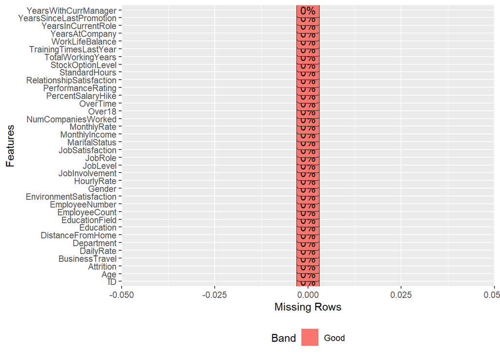

```r
plot_missing(tm_emp_data) #shows missing values using package DataExplorer
```

## Eliminating unnecessary parameter

```r
# After inspecting the data these columns can be eliminated
# This column can be eliminated as there are no observation for less than or equal to 18 years
dim(tm_emp_data[tm_emp_data$Over18 == "N",])
```

```
## [1]  0 36
```

```r
#Similarly, StandardHours and EmployeeCount
dim(tm_emp_data[tm_emp_data$EmployeeCount != 1,])
```

```
## [1]  0 36
```

```r
dim(tm_emp_data[tm_emp_data$StandardHours != 80,])
```

```
## [1]  0 36
```

```r
#Drop columns
tm_emp_data$StockOptionLevel = as.factor(tm_emp_data$StockOptionLevel)
tm_emp_data$JobSatisfaction = as.factor(tm_emp_data$JobSatisfaction)
tm_emp_data_trim1 = drop_columns(tm_emp_data, c("Over18","EmployeeCount","StandardHours") )


glimpse(tm_emp_data_trim1)
```

```
## Observations: 870
## Variables: 33
## $ ID                       <int> 1, 2, 3, 4, 5, 6, 7, 8, 9, 10, 11, 12, 13,...
## $ Age                      <int> 32, 40, 35, 32, 24, 27, 41, 37, 34, 34, 43...
## $ Attrition                <fct> No, No, No, No, No, No, No, No, No, No, No...
## $ BusinessTravel           <fct> Travel_Rarely, Travel_Rarely, Travel_Frequ...
## $ DailyRate                <int> 117, 1308, 200, 801, 567, 294, 1283, 309, ...
## $ Department               <fct> Sales, Research & Development, Research & ...
## $ DistanceFromHome         <int> 13, 14, 18, 1, 2, 10, 5, 10, 10, 10, 6, 1,...
## $ Education                <int> 4, 3, 2, 4, 1, 2, 5, 4, 4, 4, 3, 2, 3, 1, ...
## $ EducationField           <fct> Life Sciences, Medical, Life Sciences, Mar...
## $ EmployeeNumber           <int> 859, 1128, 1412, 2016, 1646, 733, 1448, 11...
## $ EnvironmentSatisfaction  <int> 2, 3, 3, 3, 1, 4, 2, 4, 3, 4, 1, 3, 3, 3, ...
## $ Gender                   <fct> Male, Male, Male, Female, Female, Male, Ma...
## $ HourlyRate               <int> 73, 44, 60, 48, 32, 32, 90, 88, 87, 92, 81...
```

[output cut: 20 more lines]

```r
## Inspect Categorical Levels
tm_emp_data_trim1_cat=inspect_cat(tm_emp_data_trim1)

tm_emp_data_trim1_cat$levels
```

```
## $Attrition
## # A tibble: 2 x 3
##   value  prop   cnt
##   <chr> <dbl> <int>
## 1 No    0.839   730
## 2 Yes   0.161   140
##
## $BusinessTravel
## # A tibble: 3 x 3
##   value              prop   cnt
##   <chr>             <dbl> <int>
## 1 Travel_Rarely     0.710   618
## 2 Travel_Frequently 0.182   158
## 3 Non-Travel        0.108    94
##
## $Department
## # A tibble: 3 x 3
##   value                    prop   cnt
##   <chr>                   <dbl> <int>
## 1 Research & Development 0.646    562
## 2 Sales                  0.314    273
## 3 Human Resources        0.0402    35
##
## $EducationField
## # A tibble: 6 x 3
##   value              prop   cnt
##   <chr>             <dbl> <int>
## 1 Life Sciences    0.411    358
## 2 Medical          0.310    270
## 3 Marketing        0.115    100
## 4 Technical Degree 0.0862    75
## 5 Other            0.0598    52
## 6 Human Resources  0.0172    15
##
## $Gender
## # A tibble: 2 x 3
##   value   prop   cnt
##   <chr>  <dbl> <int>
## 1 Male   0.593   516
## 2 Female 0.407   354
```

[output cut: 32 more lines]

```
## $OverTime
## # A tibble: 2 x 3
##   value  prop   cnt
##   <chr> <dbl> <int>
## 1 No    0.710   618
## 2 Yes   0.290   252
##
## $StockOptionLevel
## # A tibble: 4 x 3
##   value   prop   cnt
##   <chr>  <dbl> <int>
## 1 0     0.436    379
## 2 1     0.408    355
## 3 2     0.0931    81
## 4 3     0.0632    55
```

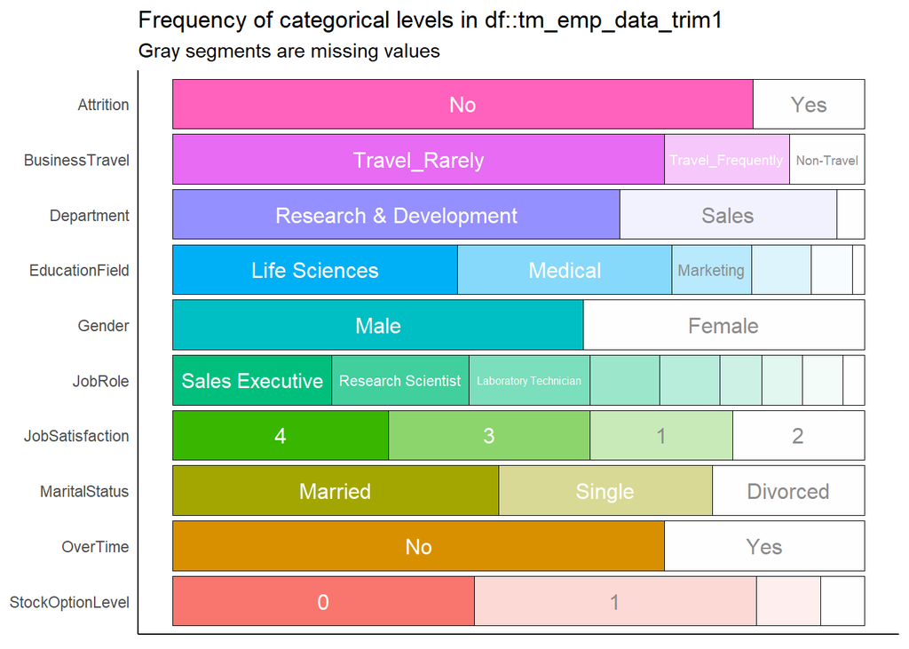

```r
show_plot(tm_emp_data_trim1_cat)
```

#Analyse correlation between all continious variables.

[figure not shown]

```r
# Correlation between all continious variables
tm_emp_data_cor_numericVal1 <- select_if(tm_emp_data_trim1, is.numeric) %>% cor()
corrplot(tm_emp_data_cor_numericVal1, method = "number",
           type = "upper",
           tl.cex = 0.8,
           tl.srt = 90,
           tl.col = "black")
```

```r
tm_emp_data_cor_numericVal1 %>% names -> num_parms
tm_emp_data_cor_numericVal1 %>% keep(is.numeric) %>% names -> num_parms
num_parms
```

[output not shown]

# MonthlyIncome, MonthlyRate, HourlyRate and DailyRate all retaled to Income. Finding how they are related.

We an see that there is no correlation at all between MonthlyIncome, MonthlyRate, HourlyRate and DailyRate

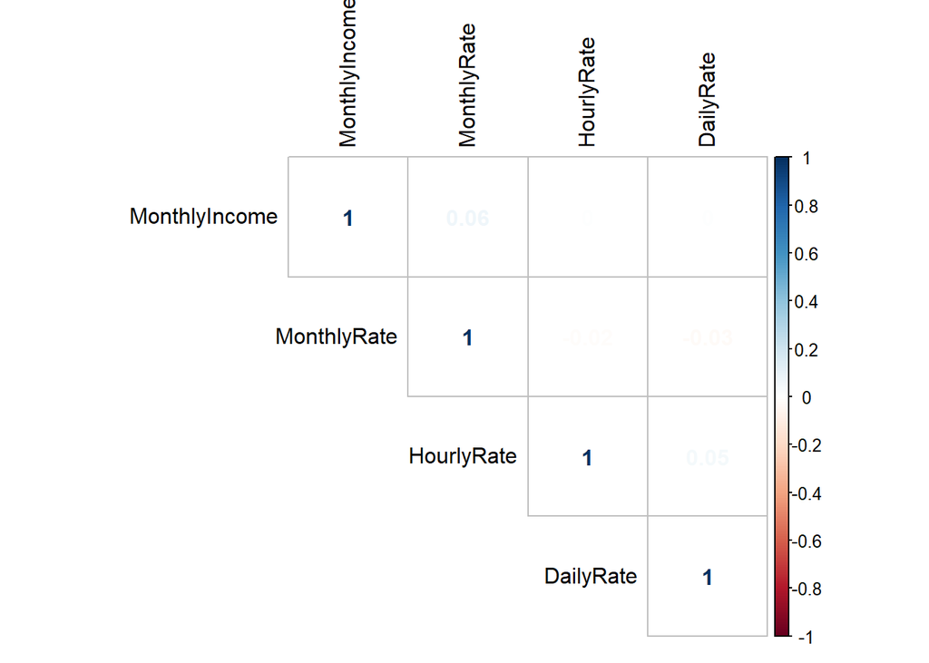

```r
tm_emp_data_cor_numericVal2 <- tm_emp_data_trim1[, c("MonthlyIncome", "MonthlyRate", "HourlyRate","DailyRate" )] %>% cor()
corrplot(tm_emp_data_cor_numericVal2, method = "number",
           type = "upper",
           tl.cex = 1,
           tl.srt = 90,
           tl.col = "black", )
```

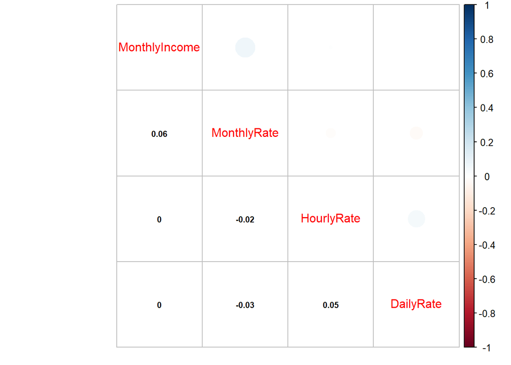

```r
corrplot.mixed(tm_emp_data_cor_numericVal2, lower.col = "black", number.cex = .7)
```

There is relation between Attrition and Monthly Income but no clear relation exists between Attrition and MonthlyRate, HourlyRate, DailyRate. We could ignore these parameters for further analysis for MonthlyIncome and Attrition

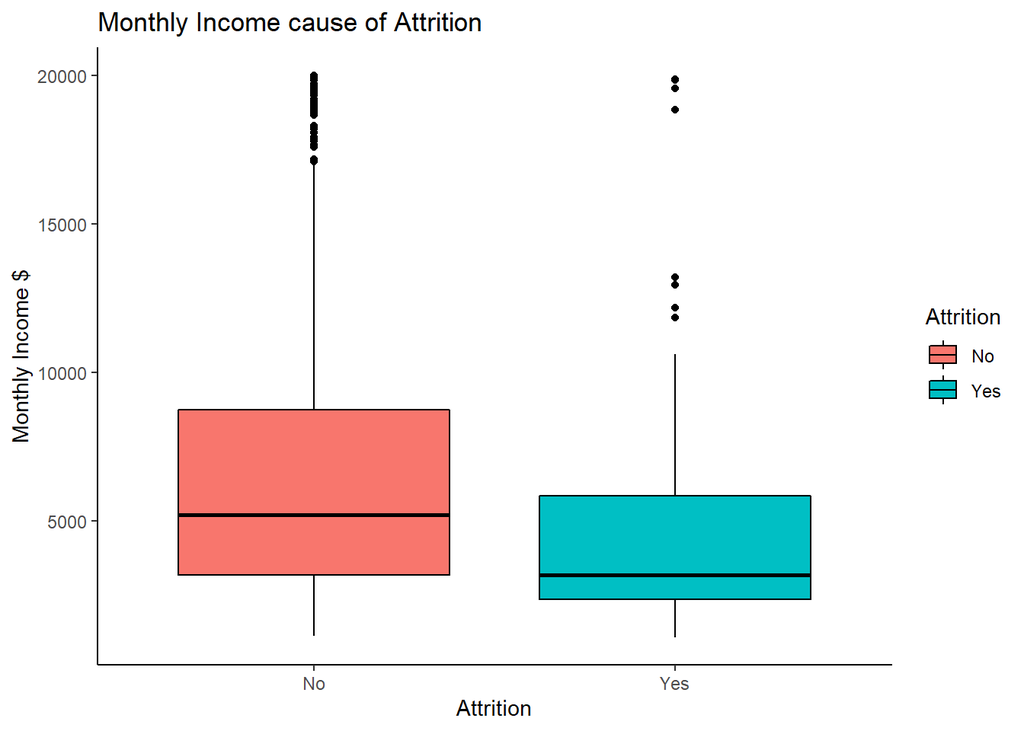

```r
# MonthlyIncome
ggplot(tm_emp_data_trim1, aes(x=Attrition, y=MonthlyIncome, color=Attrition, fill= Attrition)) +
  geom_boxplot( color = "black")+
  labs(title="Monthly Income cause of Attrition",x="Attrition", y = "Monthly Income $")
```

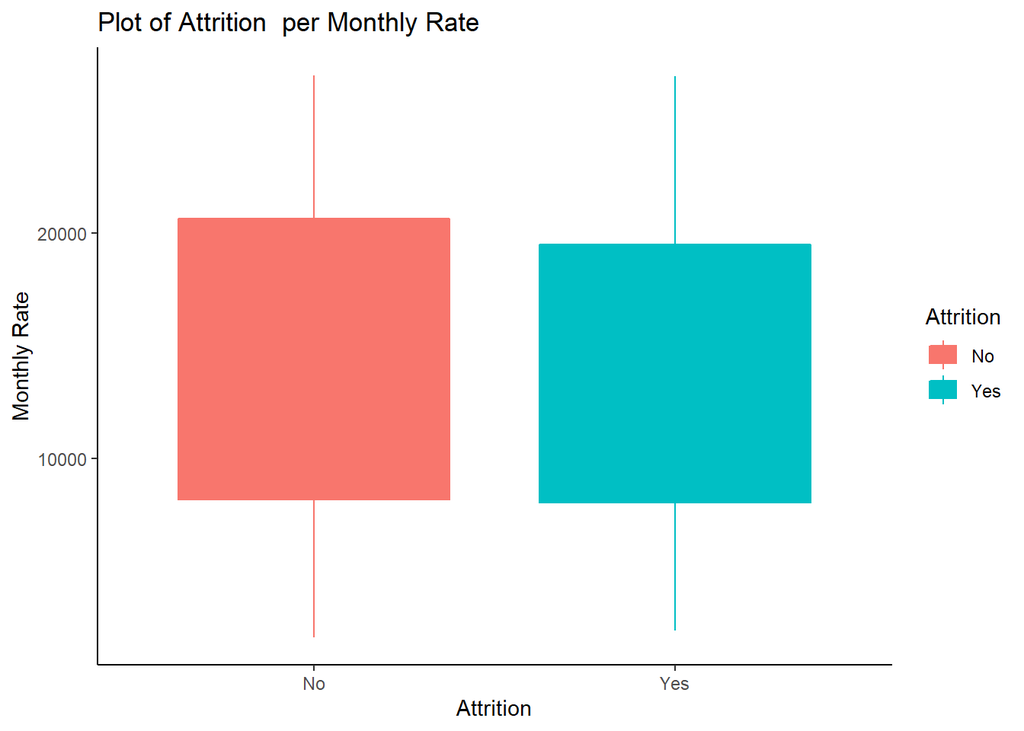

```r
# MonthlyRate
ggplot(tm_emp_data_trim1, aes(x=Attrition, y=MonthlyRate, color=Attrition, fill= Attrition)) +
  geom_boxplot()+
  labs(title="Plot of Attrition  per Monthly Rate",x="Attrition", y = "Monthly Rate")
```

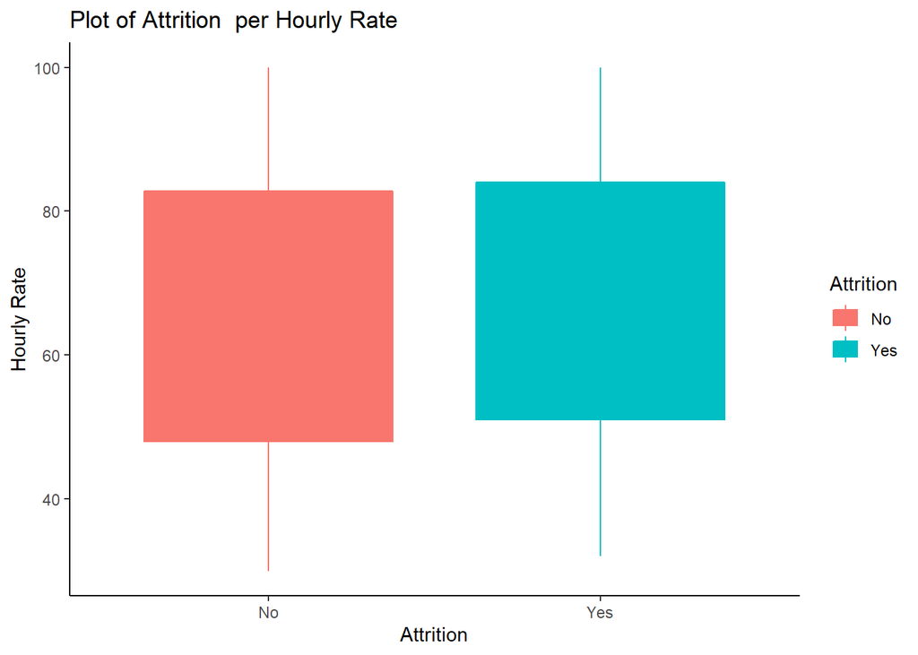

```r
# Hourly Rate
ggplot(tm_emp_data_trim1, aes(x=Attrition, y=HourlyRate, color=Attrition,  fill= Attrition)) +
  geom_boxplot()+
  labs(title="Plot of Attrition  per Hourly Rate",x="Attrition", y = "Hourly Rate")
```

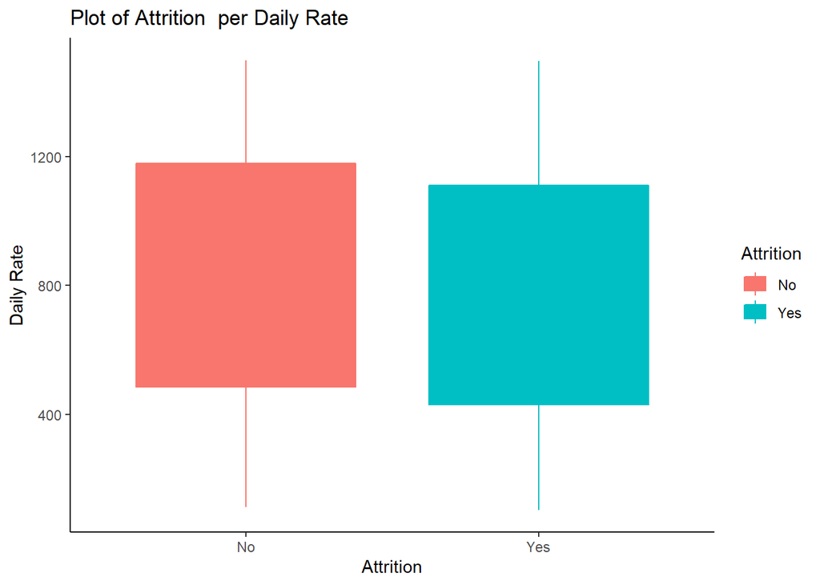

```r
# Daily Rate
ggplot(tm_emp_data_trim1, aes(x=Attrition, y=DailyRate, color=Attrition,  fill= Attrition)) +
  geom_boxplot()+
  labs(title="Plot of Attrition  per Daily Rate",x="Attrition", y = "Daily Rate")
```

*Attrition*

There are significantly more employees that do not leave their companies vs the ones that do: 730 “No” vs only 140 “Yes.” Thus we just need to keep this in mind as we look for changes in the ratios or percentages rather than the raw numbers themselves.

```r
# Attrition: Yes No Percentage
count(tm_emp_data_trim1, Attrition)
```

```
## # A tibble: 2 x 2
##   Attrition     n
##   <fct>     <int>
## 1 No          730
## 2 Yes         140
```

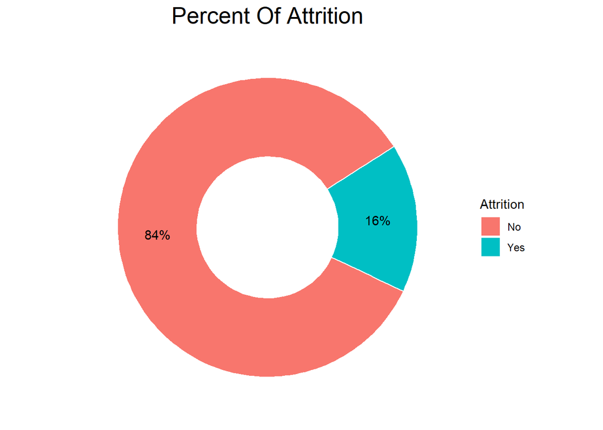

```r
att_pie = tm_emp_data_trim1%>%group_by(Attrition)%>%dplyr::summarize(count=n(),  attrition_percent = n()/nrow(tm_emp_data_trim1))
ggplot(data=att_pie,aes(x=2,y=attrition_percent,fill=Attrition))+
  geom_col(color="white")+
  coord_polar("y",start = 1)+
  geom_text(aes(label=paste0(round(attrition_percent*100),"%")),
            position = position_stack(vjust = 0.5))+
  theme(panel.background = element_blank(),
        axis.line = element_blank(),
        axis.title = element_blank(),
        axis.ticks = element_blank(),
        axis.text = element_blank(),
        plot.title = element_text(hjust = 0.5,size = I(19)))+
  ggtitle("Percent Of Attrition")+
xlim(.75,2.5)
```

#Categorical Spread

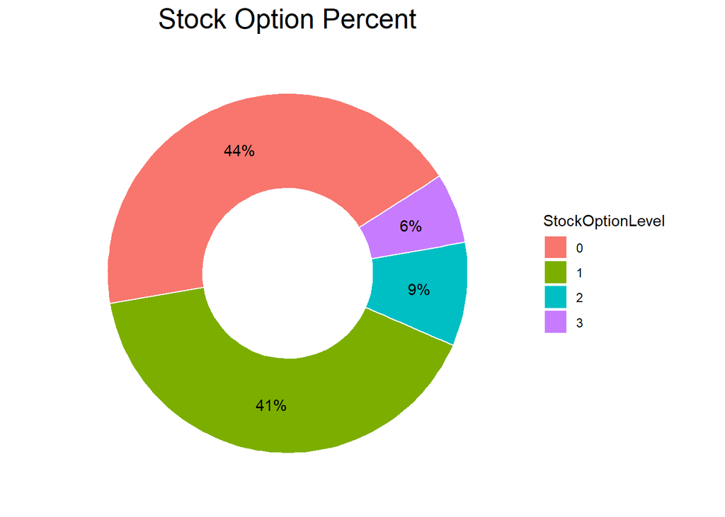

```r
#StockOptionLevel

stockoptionlevel_percent <- tm_emp_data_trim1%>%group_by(StockOptionLevel) %>% dplyr::summarize(count=n(),StockPercentage = n()/nrow(tm_emp_data_trim1))

ggplot(data=stockoptionlevel_percent,aes(x=2,y=StockPercentage,fill=StockOptionLevel))+
  geom_col(color="white")+
  coord_polar("y",start = 1)+
  geom_text(aes(label=paste0(round(StockPercentage*100),"%")),
            position = position_stack(vjust = 0.5))+
  theme(panel.background = element_blank(),
        axis.line = element_blank(),
        axis.title = element_blank(),
        axis.ticks = element_blank(),
        axis.text = element_blank(),
        plot.title = element_text(hjust = 0.5,size = I(19)))+
  ggtitle("Stock Option Percent")+
xlim(.75,2.5)
```

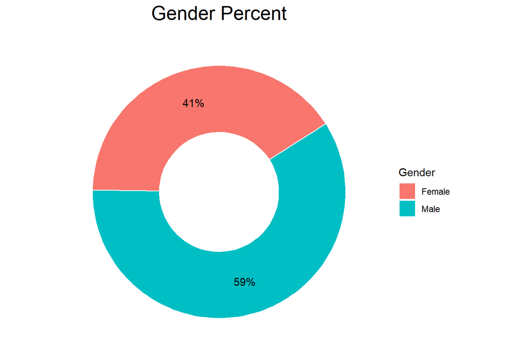

```r
#Gender

gender_percent <- tm_emp_data_trim1%>%group_by(Gender) %>% dplyr::summarize(count=n(), GenderPercentage = n()/nrow(tm_emp_data_trim1))

ggplot(data=gender_percent,aes(x=2,y=GenderPercentage,fill=Gender))+
  geom_col(color="white")+
  coord_polar("y",start = 1)+
  geom_text(aes(label=paste0(round(GenderPercentage*100),"%")),
            position = position_stack(vjust = 0.5))+
  theme(panel.background = element_blank(),
        axis.line = element_blank(),
        axis.title = element_blank(),
        axis.ticks = element_blank(),
        axis.text = element_blank(),
        plot.title = element_text(hjust = 0.5,size = I(19)))+
  ggtitle("Gender Percent")+
xlim(.75,2.5)
```

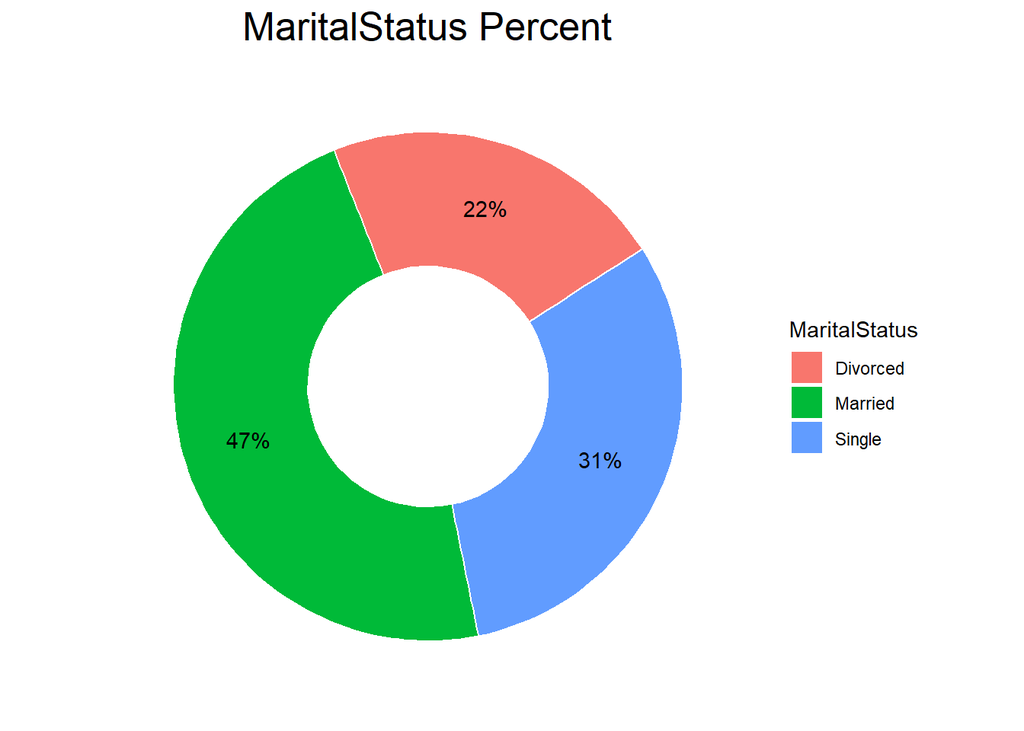

```r
#MaritalStatus

ms_percent <- tm_emp_data_trim1%>%group_by(MaritalStatus) %>% dplyr::summarize(count=n(), MaritalStatusPercentage = n()/nrow(tm_emp_data_trim1))

ggplot(data=ms_percent,aes(x=2,y=MaritalStatusPercentage,fill=MaritalStatus))+
  geom_col(color="white")+
  coord_polar("y",start = 1)+
  geom_text(aes(label=paste0(round(MaritalStatusPercentage*100),"%")),
            position = position_stack(vjust = 0.5))+
  theme(panel.background = element_blank(),
        axis.line = element_blank(),
        axis.title = element_blank(),
        axis.ticks = element_blank(),
        axis.text = element_blank(),
        plot.title = element_text(hjust = 0.5,size = I(19)))+
  ggtitle("MaritalStatus Percent")+
xlim(.75,2.5)
```

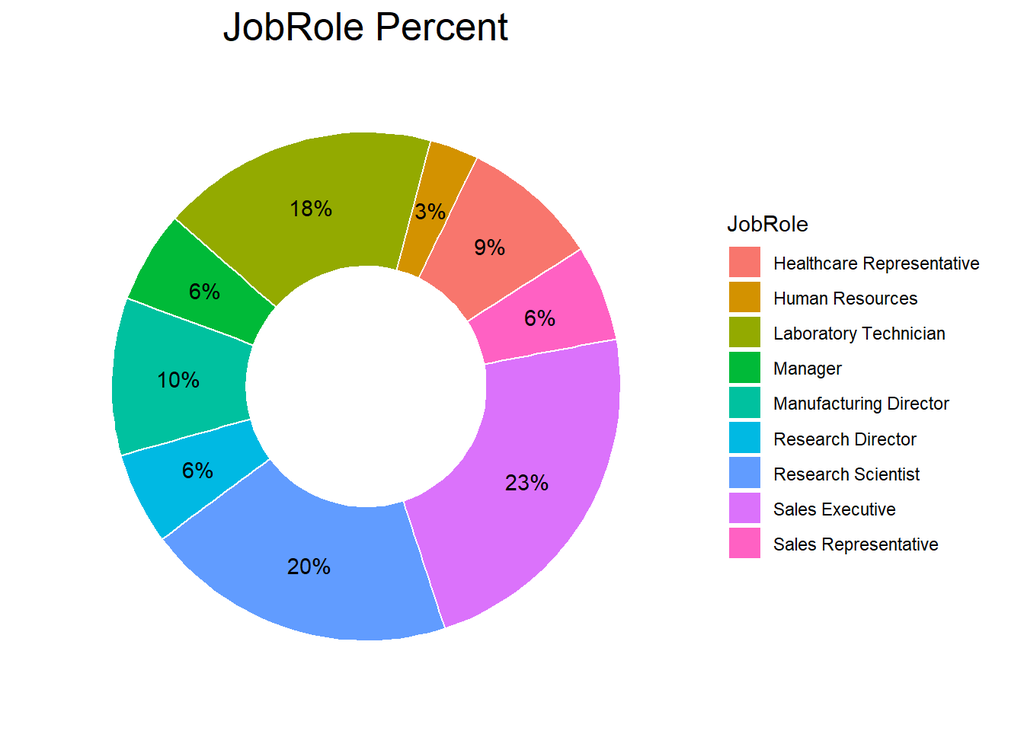

```r
#JobRole

JobRole_percent <- tm_emp_data_trim1%>%group_by(JobRole) %>% dplyr::summarize(count=n(), JobRolePercentage = n()/nrow(tm_emp_data_trim1))

ggplot(data=JobRole_percent,aes(x=2,y=JobRolePercentage,fill=JobRole))+
  geom_col(color="white")+
  coord_polar("y",start = 1)+
  geom_text(aes(label=paste0(round(JobRolePercentage*100),"%")),
            position = position_stack(vjust = 0.5))+
  theme(panel.background = element_blank(),
        axis.line = element_blank(),
        axis.title = element_blank(),
        axis.ticks = element_blank(),
        axis.text = element_blank(),
        plot.title = element_text(hjust = 0.5,size = I(19)))+
  ggtitle("JobRole Percent")+
xlim(.75,2.5)
```

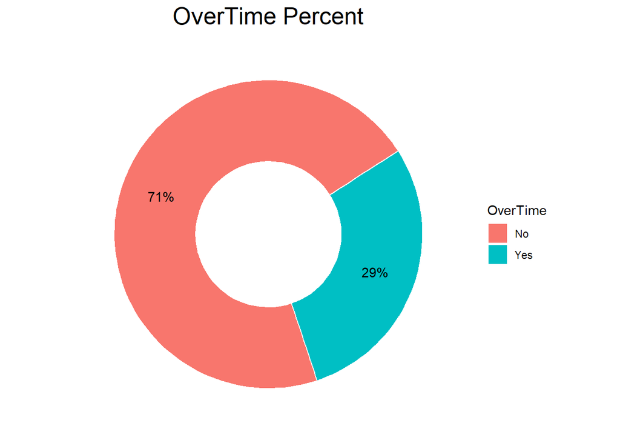

```r
#OverTime

OverTime_percent <- tm_emp_data_trim1%>%group_by(OverTime) %>% dplyr::summarize(count=n(), OverTimePercentage = n()/nrow(tm_emp_data_trim1))

ggplot(data=OverTime_percent,aes(x=2,y=OverTimePercentage,fill=OverTime))+
  geom_col(color="white")+
  coord_polar("y",start = 1)+
  geom_text(aes(label=paste0(round(OverTimePercentage*100),"%")),
            position = position_stack(vjust = 0.5))+
  theme(panel.background = element_blank(),
        axis.line = element_blank(),
        axis.title = element_blank(),
        axis.ticks = element_blank(),
        axis.text = element_blank(),
        plot.title = element_text(hjust = 0.5,size = I(19)))+
  ggtitle("OverTime Percent")+
xlim(.75,2.5)
```

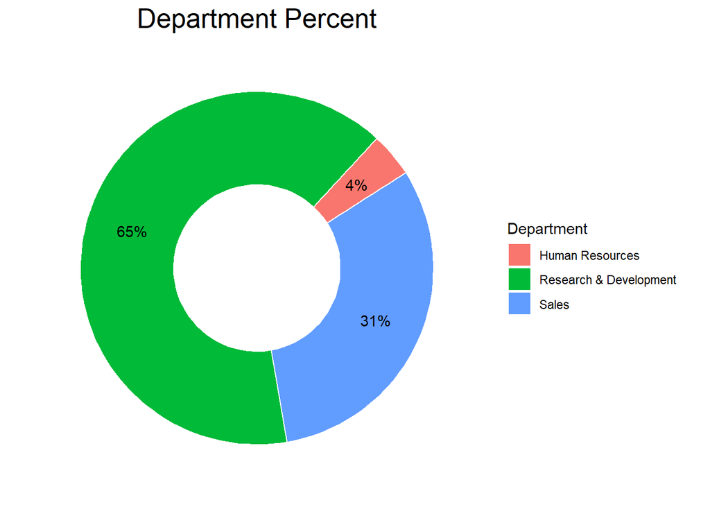

```r
#Department

Department_percent <- tm_emp_data_trim1%>%group_by(Department) %>% dplyr::summarize(count=n(), DepartmentPercentage = n()/nrow(tm_emp_data_trim1))

ggplot(data=Department_percent,aes(x=2,y=DepartmentPercentage,fill=Department))+
  geom_col(color="white")+
  coord_polar("y",start = 1)+
  geom_text(aes(label=paste0(round(DepartmentPercentage*100),"%")),
            position = position_stack(vjust = 0.5))+
  theme(panel.background = element_blank(),
        axis.line = element_blank(),
        axis.title = element_blank(),
        axis.ticks = element_blank(),
        axis.text = element_blank(),
        plot.title = element_text(hjust = 0.5,size = I(19)))+
  ggtitle("Department Percent")+
xlim(.75,2.5)
```

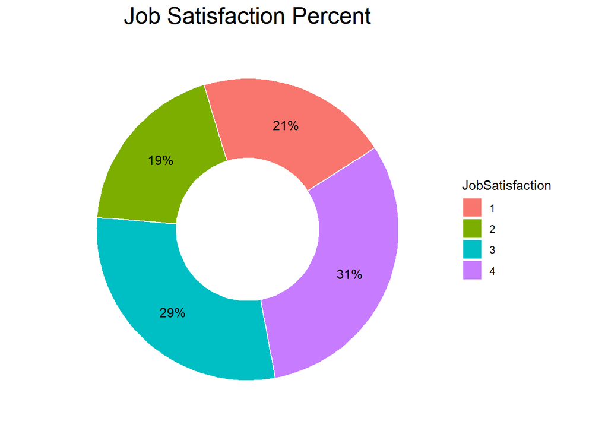

```r
#JobSatisfaction

JobSatisfaction_percent <- tm_emp_data_trim1%>%group_by(JobSatisfaction) %>%
  dplyr::summarize(count=n(), JobSatisfactionPercentage = n()/nrow(tm_emp_data_trim1))

ggplot(data=JobSatisfaction_percent,aes(x=2,y=JobSatisfactionPercentage,fill=JobSatisfaction))+
  geom_col(color="white")+
  coord_polar("y",start = 1)+
  geom_text(aes(label=paste0(round(JobSatisfactionPercentage*100),"%")),
            position = position_stack(vjust = 0.5))+
  theme(panel.background = element_blank(),
        axis.line = element_blank(),
        axis.title = element_blank(),
        axis.ticks = element_blank(),
        axis.text = element_blank(),
        plot.title = element_text(hjust = 0.5,size = I(19)))+
  ggtitle("Job Satisfaction Percent")+
xlim(.75,2.5)
```

Looking at a comparision of each the categorical variables for “Yes” vs “No” Attrition, we can see significant differences for the following:

[figure not shown]

```r
catplot_att <- function(df, x,y){
  ggplot(data = df, aes_string(x = x, fill = y)) +
    geom_bar(position = "fill", alpha = 0.9) +
    coord_flip()
}

categorical_variables1 = tm_emp_data_trim1 %>% select_if(is.factor) %>% names()
categorical_variables1 = categorical_variables1[-1]
calplot_cat_response1 <-lapply(categorical_variables1, function(x) catplot_att(tm_emp_data_trim1,x, "Attrition"))
cowplot::plot_grid(plotlist = calplot_cat_response1)
```

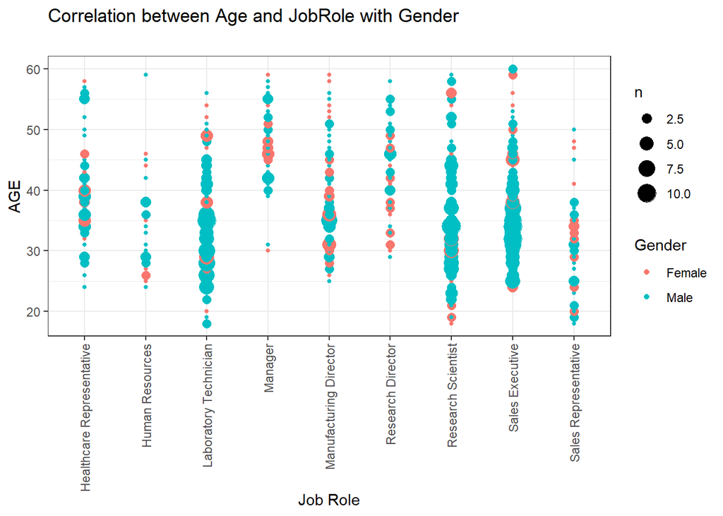

```r
theme_set(theme_bw())
ggplot(tm_emp_data_trim1, aes(JobRole, Age, color = Gender)) +
  theme(axis.text.x = element_text(angle = 90,hjust = 1,vjust = 0.5)) +
geom_count(show.legend = T) +
  labs(
    subtitle = "",
    y = "AGE",
    x = "Job Role",
    title = "Correlation between Age and JobRole with Gender"
  )
```

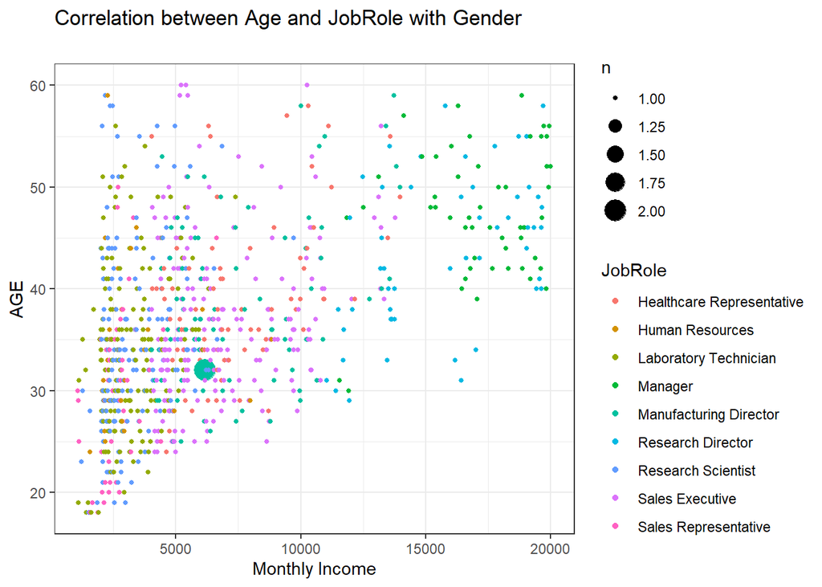

```r
theme_set(theme_bw())
ggplot(tm_emp_data_trim1, aes(MonthlyIncome, Age, color = JobRole)) +
geom_count(show.legend = T) +
  labs(
    subtitle = "",
    y = "AGE",
    x = "Monthly Income",
    title = "Correlation between Age and JobRole with Gender"
  )
```

##Objective 1

### Linear Regression Model for MonthlyIncome

#Full Model

Run a linear regression against MonthlyIncome. model shows the following as important parameters that all have p-value <= 0.05 which are significant

- BusinessTravel: Travel_Rarely
- JobLevel
- JobRole: Laboratory Technician
- JobRole: Manager
- JobRole: Research Director
- JobRole: Research Scientist
- TotalWorkingYears
- YearsSinceLastPromotion

But by running vif for the model, to identify covariance. “vif of Department is 112.890068” and “vif of JobRole is 568.584833”, which are huge. General rule of thumb vif shouldn’t be more than 10. We shall update the model to eliminate covariance.

```r
### Linear Regression on MonthlyIncome

#NOTE: Just to be safe I am mainitaining seperate ds for regression
tm_emp_data_trim1_mrl = tm_emp_data_trim1
# First create model on all variables
monthly_income_lm = lm(MonthlyIncome ~ ., data =  tm_emp_data_trim1_mrl)
summary(monthly_income_lm)
```

```
##
## Call:
## lm(formula = MonthlyIncome ~ ., data = tm_emp_data_trim1_mrl)
##
## Residuals:
##     Min      1Q  Median      3Q     Max
## -3657.5  -672.1    -0.2   634.1  4117.1
##
## Coefficients:
##                                    Estimate Std. Error t value Pr(>|t|)
## (Intercept)                       6.475e+01  7.856e+02   0.082 0.934334
## ID                               -2.366e-01  1.480e-01  -1.599 0.110201
## Age                              -1.198e+00  5.658e+00  -0.212 0.832417
## AttritionYes                      1.041e+02  1.172e+02   0.889 0.374495
## BusinessTravelTravel_Frequently   1.866e+02  1.423e+02   1.311 0.190297
## BusinessTravelTravel_Rarely       3.693e+02  1.203e+02   3.071 0.002206 **
## DailyRate                         1.455e-01  9.169e-02   1.587 0.112886
## DepartmentResearch & Development  1.135e+02  4.783e+02   0.237 0.812388
## DepartmentSales                  -4.515e+02  4.884e+02  -0.924 0.355571
## DistanceFromHome                 -5.992e+00  4.595e+00  -1.304 0.192552
## Education                        -3.797e+01  3.729e+01  -1.018 0.308895
## EducationFieldLife Sciences       1.409e+02  3.696e+02   0.381 0.703211
## EducationFieldMarketing           1.550e+02  3.919e+02   0.395 0.692658
## EducationFieldMedical             4.774e+01  3.703e+02   0.129 0.897473
## EducationFieldOther               1.035e+02  3.952e+02   0.262 0.793479
## EducationFieldTechnical Degree    1.017e+02  3.848e+02   0.264 0.791591
## EmployeeNumber                    8.808e-02  6.113e-02   1.441 0.150003
## EnvironmentSatisfaction          -8.610e+00  3.372e+01  -0.255 0.798503
## GenderMale                        1.104e+02  7.460e+01   1.480 0.139373
## HourlyRate                       -1.740e-01  1.834e+00  -0.095 0.924440
## JobInvolvement                    1.955e+01  5.334e+01   0.366 0.714111
## JobLevel                          2.788e+03  8.363e+01  33.332  < 2e-16 ***
## JobRoleHuman Resources           -1.887e+02  5.173e+02  -0.365 0.715305
## JobRoleLaboratory Technician     -5.840e+02  1.720e+02  -3.396 0.000717 ***
## JobRoleManager                    4.267e+03  2.835e+02  15.052  < 2e-16 ***
## JobRoleManufacturing Director     2.049e+02  1.708e+02   1.200 0.230535
## JobRoleResearch Director          4.099e+03  2.199e+02  18.638  < 2e-16 ***
## JobRoleResearch Scientist        -3.410e+02  1.712e+02  -1.992 0.046675 *
## JobRoleSales Executive            5.122e+02  3.590e+02   1.427 0.154083
## JobRoleSales Representative       6.612e+01  3.925e+02   0.168 0.866267
```

[output cut: 12 more lines]

```
## StockOptionLevel2                -3.847e+01  1.660e+02  -0.232 0.816802
## StockOptionLevel3                 5.094e+01  1.892e+02   0.269 0.787831
## TotalWorkingYears                 5.007e+01  1.102e+01   4.543 6.38e-06 ***
## TrainingTimesLastYear             2.462e+01  2.920e+01   0.843 0.399303
## WorkLifeBalance                  -3.143e+01  5.183e+01  -0.607 0.544331
## YearsAtCompany                   -3.391e+00  1.373e+01  -0.247 0.805042
## YearsInCurrentRole                2.686e+00  1.713e+01   0.157 0.875439
## YearsSinceLastPromotion           3.203e+01  1.536e+01   2.086 0.037294 *
## YearsWithCurrManager             -2.626e+01  1.672e+01  -1.570 0.116826
## ---
## Signif. codes:  0 '***' 0.001 '**' 0.01 '*' 0.05 '.' 0.1 ' ' 1
##
## Residual standard error: 1056 on 819 degrees of freedom
## Multiple R-squared:  0.9503, Adjusted R-squared:  0.9472
## F-statistic: 312.9 on 50 and 819 DF,  p-value: < 2.2e-16
```

```r
# Then test for VIF
vif(monthly_income_lm)
```

```
##                                GVIF Df GVIF^(1/(2*Df))
## ID                         1.077035  1        1.037803
## Age                        1.986360  1        1.409383
## Attrition                  1.445824  1        1.202424
## BusinessTravel             1.132588  2        1.031616
## DailyRate                  1.053717  1        1.026507
## Department               112.890068  2        3.259597
## DistanceFromHome           1.088616  1        1.043367
## Education                  1.133724  1        1.064765
## EducationField             3.105306  5        1.119980
## EmployeeNumber             1.064572  1        1.031781
## EnvironmentSatisfaction    1.070143  1        1.034477
## Gender                     1.047351  1        1.023402
## HourlyRate                 1.061441  1        1.030262
## JobInvolvement             1.097261  1        1.047502
## JobLevel                   6.474464  1        2.544497
## JobRole                  568.584833  8        1.486534
## JobSatisfaction            1.201121  3        1.031014
## MaritalStatus              3.113704  2        1.328371
## MonthlyRate                1.045140  1        1.022321
## NumCompaniesWorked         1.419604  1        1.191471
## OverTime                   1.149765  1        1.072271
## PercentSalaryHike          2.644668  1        1.626243
## PerformanceRating          2.633710  1        1.622871
## RelationshipSatisfaction   1.059056  1        1.029104
## StockOptionLevel           3.316291  3        1.221168
## TotalWorkingYears          5.340960  1        2.311052
## TrainingTimesLastYear      1.075659  1        1.037140
## WorkLifeBalance            1.060604  1        1.029856
## YearsAtCompany             5.325391  1        2.307681
## YearsInCurrentRole         3.028269  1        1.740192
## YearsSinceLastPromotion    1.864081  1        1.365313
## YearsWithCurrManager       2.783716  1        1.668447
```

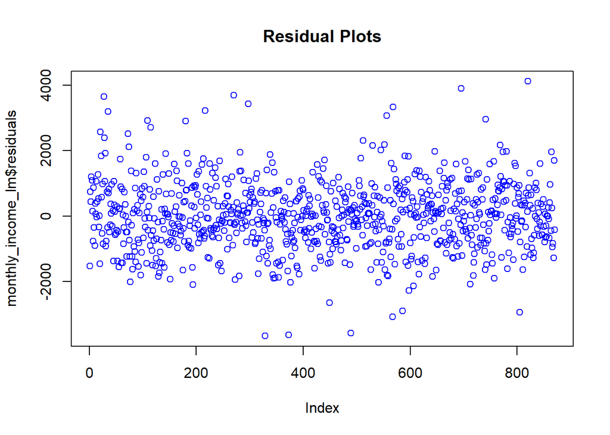

```r
plot(monthly_income_lm$residuals, col="blue", main="Residual Plots")
```

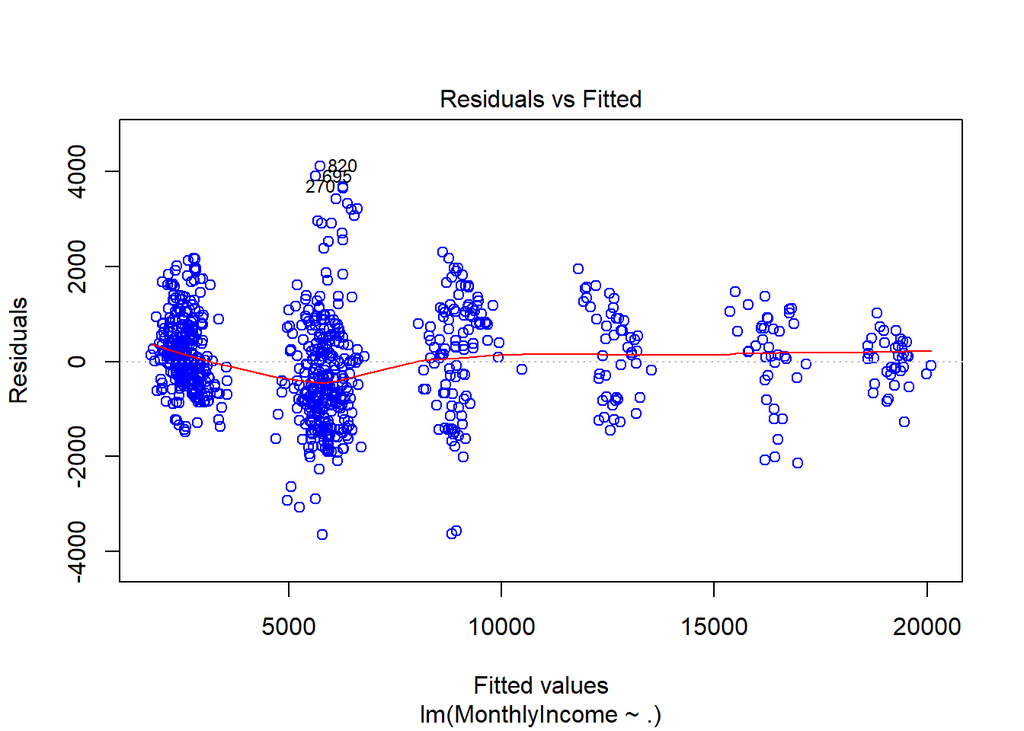

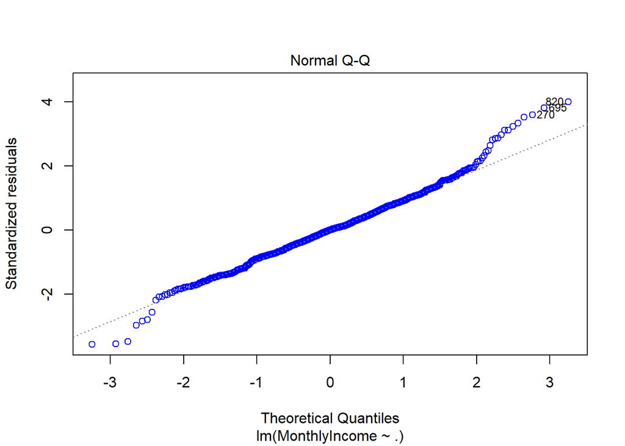

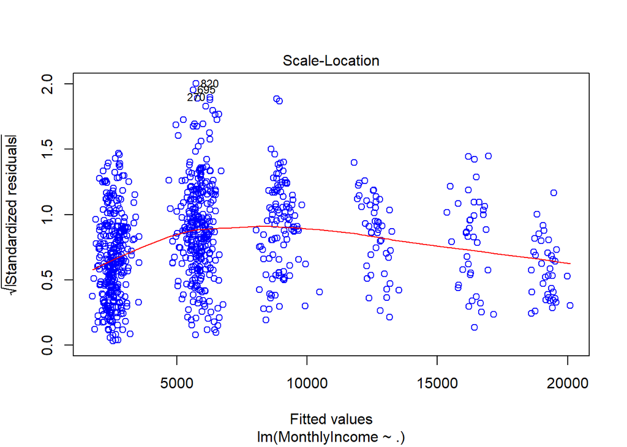

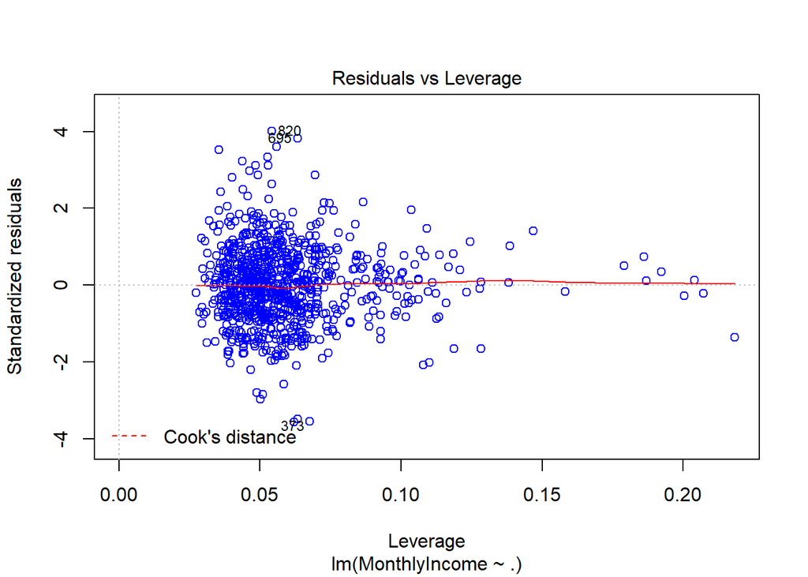

```r
plot(monthly_income_lm, col="blue")
```

New Model looks much better in terms of covarince by eliminating Department and JobRole

```r
# Rerun with JobRole and Department removed
tm_emp_data_trim1_mrl_trim = tm_emp_data_trim1_mrl[,-c(6,16)]
# create model on remaining variables
monthly_income_lm = lm(MonthlyIncome ~ ., data =  tm_emp_data_trim1_mrl_trim)
summary(monthly_income_lm)
```

```
##
## Call:
## lm(formula = MonthlyIncome ~ ., data = tm_emp_data_trim1_mrl_trim)
##
## Residuals:
##     Min      1Q  Median      3Q     Max
## -5896.6  -799.1   -19.0   750.7  4397.3
##
## Coefficients:
##                                   Estimate Std. Error t value Pr(>|t|)
## (Intercept)                     -1.218e+03  8.149e+02  -1.494  0.13552
## ID                              -2.197e-01  1.909e-01  -1.151  0.25012
## Age                             -2.172e+00  7.304e+00  -0.297  0.76630
## AttritionYes                     1.042e+02  1.497e+02   0.696  0.48644
## BusinessTravelTravel_Frequently -2.014e+00  1.832e+02  -0.011  0.99123
## BusinessTravelTravel_Rarely      3.136e+02  1.551e+02   2.022  0.04347 *
## DailyRate                       -5.633e-02  1.185e-01  -0.475  0.63471
## DistanceFromHome                -1.578e+01  5.934e+00  -2.659  0.00798 **
## Education                        9.101e+00  4.801e+01   0.190  0.84970
## EducationFieldLife Sciences     -3.064e+02  3.703e+02  -0.827  0.40823
## EducationFieldMarketing         -6.649e+02  3.890e+02  -1.709  0.08775 .
## EducationFieldMedical           -2.491e+02  3.718e+02  -0.670  0.50316
## EducationFieldOther             -3.634e+02  4.092e+02  -0.888  0.37483
## EducationFieldTechnical Degree  -3.096e+02  3.958e+02  -0.782  0.43422
## EmployeeNumber                   4.747e-02  7.884e-02   0.602  0.54725
## EnvironmentSatisfaction         -6.285e+01  4.341e+01  -1.448  0.14802
## GenderMale                       6.638e+01  9.655e+01   0.688  0.49192
## HourlyRate                       1.874e+00  2.377e+00   0.788  0.43071
## JobInvolvement                   9.718e+01  6.878e+01   1.413  0.15803
## JobLevel                         3.759e+03  7.060e+01  53.247  < 2e-16 ***
## JobSatisfaction2                -6.348e+01  1.495e+02  -0.425  0.67114
## JobSatisfaction3                -4.385e+01  1.370e+02  -0.320  0.74907
## JobSatisfaction4                 1.802e+01  1.367e+02   0.132  0.89513
## MaritalStatusMarried             1.517e+02  1.304e+02   1.164  0.24486
## MaritalStatusSingle              2.491e+01  2.033e+02   0.123  0.90251
## MonthlyRate                     -6.408e-03  6.685e-03  -0.959  0.33806
## NumCompaniesWorked              -1.271e+01  2.183e+01  -0.582  0.56047
## OverTimeYes                      1.108e+00  1.090e+02   0.010  0.99189
## PercentSalaryHike                3.227e+01  2.046e+01   1.577  0.11514
## PerformanceRating               -3.004e+02  2.084e+02  -1.441  0.14987
## RelationshipSatisfaction         2.665e+01  4.341e+01   0.614  0.53942
## StockOptionLevel1                6.665e+01  1.591e+02   0.419  0.67539
## StockOptionLevel2               -6.324e+01  2.143e+02  -0.295  0.76802
## StockOptionLevel3               -1.651e+01  2.443e+02  -0.068  0.94616
## TotalWorkingYears                7.036e+01  1.402e+01   5.018 6.38e-07 ***
## TrainingTimesLastYear            2.290e+01  3.760e+01   0.609  0.54268
## WorkLifeBalance                 -1.816e+01  6.701e+01  -0.271  0.78651
## YearsAtCompany                  -1.205e+01  1.765e+01  -0.683  0.49484
## YearsInCurrentRole              -1.051e+01  2.201e+01  -0.478  0.63308
## YearsSinceLastPromotion          6.791e+00  1.981e+01   0.343  0.73181
## YearsWithCurrManager            -4.352e+01  2.154e+01  -2.021  0.04362 *
## ---
## Signif. codes:  0 '***' 0.001 '**' 0.01 '*' 0.05 '.' 0.1 ' ' 1
##
## Residual standard error: 1374 on 829 degrees of freedom
## Multiple R-squared:  0.9149, Adjusted R-squared:  0.9107
## F-statistic: 222.7 on 40 and 829 DF,  p-value: < 2.2e-16
```

```r
# Then test for VIF
vif(monthly_income_lm)
```

```
##                              GVIF Df GVIF^(1/(2*Df))
## ID                       1.059883  1        1.029506
## Age                      1.957772  1        1.399204
## Attrition                1.395614  1        1.181361
## BusinessTravel           1.092934  2        1.022465
## DailyRate                1.040865  1        1.020228
## DistanceFromHome         1.073738  1        1.036213
## Education                1.111081  1        1.054078
## EducationField           1.253982  5        1.022890
## EmployeeNumber           1.047229  1        1.023342
## EnvironmentSatisfaction  1.048867  1        1.024142
## Gender                   1.037240  1        1.018450
## HourlyRate               1.054521  1        1.026899
## JobInvolvement           1.078652  1        1.038582
## JobLevel                 2.727731  1        1.651584
## JobSatisfaction          1.157373  3        1.024658
## MaritalStatus            2.996939  2        1.315738
## MonthlyRate              1.040056  1        1.019831
## NumCompaniesWorked       1.394523  1        1.180899
## OverTime                 1.127143  1        1.061670
## PercentSalaryHike        2.605463  1        1.614145
## PerformanceRating        2.577525  1        1.605467
## RelationshipSatisfaction 1.054953  1        1.027109
## StockOptionLevel         3.178949  3        1.212590
## TotalWorkingYears        5.111126  1        2.260780
## TrainingTimesLastYear    1.054401  1        1.026840
## WorkLifeBalance          1.048514  1        1.023970
## YearsAtCompany           5.199662  1        2.280277
## YearsInCurrentRole       2.955232  1        1.719079
## YearsSinceLastPromotion  1.834071  1        1.354279
## YearsWithCurrManager     2.729693  1        1.652178
```

```r
# model
summary(monthly_income_lm)
```

```
##
## Call:
## lm(formula = MonthlyIncome ~ ., data = tm_emp_data_trim1_mrl_trim)
##
## Residuals:
##     Min      1Q  Median      3Q     Max
## -5896.6  -799.1   -19.0   750.7  4397.3
##
## Coefficients:
##                                   Estimate Std. Error t value Pr(>|t|)
## (Intercept)                     -1.218e+03  8.149e+02  -1.494  0.13552
## ID                              -2.197e-01  1.909e-01  -1.151  0.25012
## Age                             -2.172e+00  7.304e+00  -0.297  0.76630
## AttritionYes                     1.042e+02  1.497e+02   0.696  0.48644
## BusinessTravelTravel_Frequently -2.014e+00  1.832e+02  -0.011  0.99123
## BusinessTravelTravel_Rarely      3.136e+02  1.551e+02   2.022  0.04347 *
## DailyRate                       -5.633e-02  1.185e-01  -0.475  0.63471
## DistanceFromHome                -1.578e+01  5.934e+00  -2.659  0.00798 **
## Education                        9.101e+00  4.801e+01   0.190  0.84970
## EducationFieldLife Sciences     -3.064e+02  3.703e+02  -0.827  0.40823
## EducationFieldMarketing         -6.649e+02  3.890e+02  -1.709  0.08775 .
## EducationFieldMedical           -2.491e+02  3.718e+02  -0.670  0.50316
## EducationFieldOther             -3.634e+02  4.092e+02  -0.888  0.37483
## EducationFieldTechnical Degree  -3.096e+02  3.958e+02  -0.782  0.43422
## EmployeeNumber                   4.747e-02  7.884e-02   0.602  0.54725
## EnvironmentSatisfaction         -6.285e+01  4.341e+01  -1.448  0.14802
## GenderMale                       6.638e+01  9.655e+01   0.688  0.49192
## HourlyRate                       1.874e+00  2.377e+00   0.788  0.43071
## JobInvolvement                   9.718e+01  6.878e+01   1.413  0.15803
## JobLevel                         3.759e+03  7.060e+01  53.247  < 2e-16 ***
## JobSatisfaction2                -6.348e+01  1.495e+02  -0.425  0.67114
## JobSatisfaction3                -4.385e+01  1.370e+02  -0.320  0.74907
## JobSatisfaction4                 1.802e+01  1.367e+02   0.132  0.89513
## MaritalStatusMarried             1.517e+02  1.304e+02   1.164  0.24486
## MaritalStatusSingle              2.491e+01  2.033e+02   0.123  0.90251
## MonthlyRate                     -6.408e-03  6.685e-03  -0.959  0.33806
## NumCompaniesWorked              -1.271e+01  2.183e+01  -0.582  0.56047
## OverTimeYes                      1.108e+00  1.090e+02   0.010  0.99189
## PercentSalaryHike                3.227e+01  2.046e+01   1.577  0.11514
## PerformanceRating               -3.004e+02  2.084e+02  -1.441  0.14987
## RelationshipSatisfaction         2.665e+01  4.341e+01   0.614  0.53942
## StockOptionLevel1                6.665e+01  1.591e+02   0.419  0.67539
## StockOptionLevel2               -6.324e+01  2.143e+02  -0.295  0.76802
## StockOptionLevel3               -1.651e+01  2.443e+02  -0.068  0.94616
## TotalWorkingYears                7.036e+01  1.402e+01   5.018 6.38e-07 ***
## TrainingTimesLastYear            2.290e+01  3.760e+01   0.609  0.54268
## WorkLifeBalance                 -1.816e+01  6.701e+01  -0.271  0.78651
## YearsAtCompany                  -1.205e+01  1.765e+01  -0.683  0.49484
## YearsInCurrentRole              -1.051e+01  2.201e+01  -0.478  0.63308
## YearsSinceLastPromotion          6.791e+00  1.981e+01   0.343  0.73181
## YearsWithCurrManager            -4.352e+01  2.154e+01  -2.021  0.04362 *
## ---
## Signif. codes:  0 '***' 0.001 '**' 0.01 '*' 0.05 '.' 0.1 ' ' 1
##
## Residual standard error: 1374 on 829 degrees of freedom
## Multiple R-squared:  0.9149, Adjusted R-squared:  0.9107
## F-statistic: 222.7 on 40 and 829 DF,  p-value: < 2.2e-16
```

### Stepwise Selection

After reducing covariance, create a new model with Stepwise Selection.

And the Adjusted R-squared is 0.9128, which means an estimated 91.28% of the MonthlyIncome variable can be accounted for by this model.

```r
# set method to use 5-fold cross-validation
trainControl(method = "cv", number = 5) -> traincontrol_cv

monthly_income_lm_step = train(MonthlyIncome ~ .,
  data = tm_emp_data_trim1_mrl_trim,
  method = "lmStepAIC",
  trControl = traincontrol_cv
)
```

```
## Start:  AIC=10108.79
## .outcome ~ ID + Age + AttritionYes + BusinessTravelTravel_Frequently +
##     BusinessTravelTravel_Rarely + DailyRate + DistanceFromHome +
##     Education + `EducationFieldLife Sciences` + EducationFieldMarketing +
##     EducationFieldMedical + EducationFieldOther + `EducationFieldTechnical Degree` +
##     EmployeeNumber + EnvironmentSatisfaction + GenderMale + HourlyRate +
##     JobInvolvement + JobLevel + JobSatisfaction2 + JobSatisfaction3 +
##     JobSatisfaction4 + MaritalStatusMarried + MaritalStatusSingle +
##     MonthlyRate + NumCompaniesWorked + OverTimeYes + PercentSalaryHike +
##     PerformanceRating + RelationshipSatisfaction + StockOptionLevel1 +
##     StockOptionLevel2 + StockOptionLevel3 + TotalWorkingYears +
##     TrainingTimesLastYear + WorkLifeBalance + YearsAtCompany +
##     YearsInCurrentRole + YearsSinceLastPromotion + YearsWithCurrManager
##
##                                    Df  Sum of Sq        RSS   AIC
## - MonthlyRate                       1        561 1256579525 10107
## - DailyRate                         1      14386 1256593350 10107
## - WorkLifeBalance                   1      23736 1256602700 10107
## - JobSatisfaction4                  1      24716 1256603680 10107
## - YearsInCurrentRole                1      38491 1256617455 10107
## - StockOptionLevel1                 1      51595 1256630559 10107
## - GenderMale                        1      62147 1256641111 10107
## - TrainingTimesLastYear             1      68056 1256647020 10107
## - HourlyRate                        1      74614 1256653578 10107
## - StockOptionLevel2                 1     159125 1256738089 10107
## - StockOptionLevel3                 1     167904 1256746868 10107
## - MaritalStatusSingle               1     179102 1256758066 10107
## - `EducationFieldTechnical Degree`  1     187424 1256766388 10107
## - BusinessTravelTravel_Frequently   1     206765 1256785729 10107
## - Age                               1     302423 1256881387 10107
## - OverTimeYes                       1     406467 1256985431 10107
## - `EducationFieldLife Sciences`     1     463619 1257042583 10107
## - EducationFieldOther               1     641239 1257220203 10107
## - EducationFieldMedical             1     647999 1257226963 10107
## - EmployeeNumber                    1     679169 1257258133 10107
## - JobSatisfaction3                  1     690094 1257269058 10107
## - YearsSinceLastPromotion           1     750858 1257329822 10107
## - YearsAtCompany                    1     927272 1257506236 10107
## - JobSatisfaction2                  1    1000427 1257579391 10107
## - NumCompaniesWorked                1    1124230 1257703194 10107
```

[output cut: 7032 more lines]

```
## .outcome ~ BusinessTravelTravel_Rarely + DistanceFromHome + EducationFieldMarketing +
##     EnvironmentSatisfaction + JobInvolvement + JobLevel + MaritalStatusMarried +
##     TotalWorkingYears + YearsWithCurrManager
##
##                               Df  Sum of Sq        RSS   AIC
## <none>                                      1585015846 12561
## - JobInvolvement               1    3932348 1588948194 12562
## - MaritalStatusMarried         1    3970026 1588985873 12562
## - EnvironmentSatisfaction      1    4979154 1589995000 12562
## - DistanceFromHome             1   12838996 1597854842 12566
## - EducationFieldMarketing      1   12878775 1597894622 12566
## - BusinessTravelTravel_Rarely  1   16737293 1601753139 12568
## - YearsWithCurrManager         1   29408237 1614424083 12575
## - TotalWorkingYears            1   70832125 1655847971 12597
## - JobLevel                     1 5548821138 7133836984 13868
```

```r
# Final model
summary(monthly_income_lm_step)
```

```
##
## Call:
## lm(formula = .outcome ~ BusinessTravelTravel_Rarely + DistanceFromHome +
##     EducationFieldMarketing + EnvironmentSatisfaction + JobInvolvement +
##     JobLevel + MaritalStatusMarried + TotalWorkingYears + YearsWithCurrManager,
##     data = dat)
##
## Residuals:
##     Min      1Q  Median      3Q     Max
## -5857.8  -761.3     0.4   735.0  4244.8
##
## Coefficients:
##                              Estimate Std. Error t value Pr(>|t|)
## (Intercept)                 -1887.027    253.357  -7.448 2.30e-13 ***
## BusinessTravelTravel_Rarely   308.194    102.270   3.014  0.00266 **
## DistanceFromHome              -15.086      5.716  -2.639  0.00846 **
## EducationFieldMarketing      -385.885    145.978  -2.643  0.00836 **
## EnvironmentSatisfaction       -68.977     41.965  -1.644  0.10061
## JobInvolvement                 95.713     65.526   1.461  0.14447
## JobLevel                     3745.203     68.256  54.870  < 2e-16 ***
## MaritalStatusMarried          137.169     93.461   1.468  0.14256
## TotalWorkingYears              64.114     10.342   6.199 8.79e-10 ***
## YearsWithCurrManager          -58.150     14.557  -3.995 7.04e-05 ***
## ---
## Signif. codes:  0 '***' 0.001 '**' 0.01 '*' 0.05 '.' 0.1 ' ' 1
##
## Residual standard error: 1358 on 860 degrees of freedom
## Multiple R-squared:  0.9137, Adjusted R-squared:  0.9128
## F-statistic:  1012 on 9 and 860 DF,  p-value: < 2.2e-16
```

```r
# Results including RMSE of final model
monthly_income_lm_step$results
```

```
##   parameter     RMSE  Rsquared      MAE   RMSESD RsquaredSD    MAESD
## 1      none 1389.491 0.9090417 1044.597 69.91751 0.01619446 42.55519
```

### MonthlyIncome Predictions

*Training Data*

```r
# generating predictions on test data
tm_emp_data$MonthlyIncome_LM <- predict(monthly_income_lm_step, newdata = tm_emp_data)


# Prediction Error for Linear Regression
RMSE(tm_emp_data$MonthlyIncome_LM, tm_emp_data$MonthlyIncome) / mean(tm_emp_data$MonthlyIncome)
```

```
## [1] 0.2112216
```

*Test Data*

Predict the MonthlyIncome in the csv file provided CompSet_NoSalary.csv which do not have MonthlyIncome

```r
# loading prediction data
MonthlyIncome_pred <- read.csv("https://raw.githubusercontent.com/rajeshsk/DDS-Project-Two/master/Data/CaseStudy2CompSet%20No%20Salary.csv", sep = ",",  header = TRUE)
#read CompSet_NoSalary.csv
#MonthlyIncome_pred = read.csv(file.choose(),header = TRUE, sep = ',')

str(MonthlyIncome_pred)
```

```
## 'data.frame':    300 obs. of  35 variables:
##  $ ï..ID                   : int  871 872 873 874 875 876 877 878 879 880 ...
##  $ Age                     : int  43 33 55 36 27 39 33 21 30 51 ...
##  $ Attrition               : Factor w/ 2 levels "No","Yes": 1 1 2 1 1 2 1 2 1 1 ...
##  $ BusinessTravel          : Factor w/ 3 levels "Non-Travel","Travel_Frequently",..: 2 3 3 1 3 3 1 2 2 3 ...
##  $ DailyRate               : int  1422 461 267 1351 1302 895 750 251 1312 1405 ...
##  $ Department              : Factor w/ 3 levels "Human Resources",..: 3 2 3 2 2 3 3 2 2 2 ...
##  $ DistanceFromHome        : int  2 13 13 9 19 5 22 10 23 11 ...
##  $ Education               : int  4 1 4 4 3 3 2 2 3 2 ...
##  $ EducationField          : Factor w/ 6 levels "Human Resources",..: 2 2 3 2 5 6 3 2 2 6 ...
##  $ EmployeeCount           : int  1 1 1 1 1 1 1 1 1 1 ...
##  $ EmployeeNumber          : int  1849 995 1372 1949 1619 42 160 1279 159 1367 ...
##  $ EnvironmentSatisfaction : int  1 2 1 1 4 4 3 1 1 4 ...
##  $ Gender                  : Factor w/ 2 levels "Female","Male": 2 1 2 2 2 2 2 1 2 1 ...
##  $ HourlyRate              : int  92 53 85 66 67 56 95 45 96 82 ...
```

[output cut: 21 more lines]

```r
head(MonthlyIncome_pred)
```

```
##   ï..ID Age Attrition    BusinessTravel DailyRate             Department
## 1   871  43        No Travel_Frequently      1422                  Sales
## 2   872  33        No     Travel_Rarely       461 Research & Development
## 3   873  55       Yes     Travel_Rarely       267                  Sales
## 4   874  36        No        Non-Travel      1351 Research & Development
## 5   875  27        No     Travel_Rarely      1302 Research & Development
## 6   876  39       Yes     Travel_Rarely       895                  Sales
##   DistanceFromHome Education   EducationField EmployeeCount EmployeeNumber
## 1                2         4    Life Sciences             1           1849
## 2               13         1    Life Sciences             1            995
## 3               13         4        Marketing             1           1372
## 4                9         4    Life Sciences             1           1949
## 5               19         3            Other             1           1619
## 6                5         3 Technical Degree             1             42
##   EnvironmentSatisfaction Gender HourlyRate JobInvolvement JobLevel
```

[output cut: 41 more lines]

```r
colnames(MonthlyIncome_pred)[colnames(MonthlyIncome_pred) == "ï..ID"] <- "ID"

MonthlyIncome_pred$StockOptionLevel = as.factor(MonthlyIncome_pred$StockOptionLevel)
MonthlyIncome_pred$JobSatisfaction = as.factor(MonthlyIncome_pred$JobSatisfaction)

# generating predictions on test data
MonthlyIncome_pred$MonthlyIncome_LM <- predict(monthly_income_lm_step, newdata = MonthlyIncome_pred)

 write.csv(MonthlyIncome_pred[c("ID", "MonthlyIncome_LM")], "C:\\Users\\SATRK001\\Case2PredictionsRegress_MonthlyIncome_RajeshSatluri.csv")
```

## Attrition

#Classification using KNN

We will calculate Confusion Matrix and Statistics

Accuracy: correct results / all results Sensitivity: correctly predicted Attrition:No / All actual “No” Specificity: correctly predicted Attrition:Yes / All actual “Yes”

Split the data into 80% training and 20% for testing

```r
### Split the data into 80% training and 20% for testing

attrition_vector <- createDataPartition(tm_emp_data_trim1$Attrition, p = 0.8, list = F)
attrition_train <- tm_emp_data_trim1[attrition_vector,]
attrition_test <- tm_emp_data_trim1[-attrition_vector,]

# validate train and test sets
head(attrition_train)
```

```
##   ID Age Attrition    BusinessTravel DailyRate             Department
## 1  1  32        No     Travel_Rarely       117                  Sales
## 2  2  40        No     Travel_Rarely      1308 Research & Development
## 3  3  35        No Travel_Frequently       200 Research & Development
## 4  4  32        No     Travel_Rarely       801                  Sales
## 5  5  24        No Travel_Frequently       567 Research & Development
## 6  6  27        No Travel_Frequently       294 Research & Development
##   DistanceFromHome Education   EducationField EmployeeNumber
## 1               13         4    Life Sciences            859
## 2               14         3          Medical           1128
## 3               18         2    Life Sciences           1412
## 4                1         4        Marketing           2016
## 5                2         1 Technical Degree           1646
## 6               10         2    Life Sciences            733
##   EnvironmentSatisfaction Gender HourlyRate JobInvolvement JobLevel
```

[output cut: 41 more lines]

```r
head(attrition_test)
```

```
##    ID Age Attrition BusinessTravel DailyRate             Department
## 9   9  34        No  Travel_Rarely      1333                  Sales
## 11 11  43        No  Travel_Rarely       823 Research & Development
## 14 14  30        No  Travel_Rarely       202                  Sales
## 16 16  31        No     Non-Travel      1188                  Sales
## 18 18  46        No     Non-Travel      1144 Research & Development
## 22 22  48        No  Travel_Rarely       817                  Sales
##    DistanceFromHome Education   EducationField EmployeeNumber
## 9                10         4    Life Sciences           1055
## 11                6         3          Medical           1866
## 14                2         1 Technical Degree            508
## 16               20         2        Marketing            947
## 18                7         4          Medical            487
## 22                2         1        Marketing            712
##    EnvironmentSatisfaction Gender HourlyRate JobInvolvement JobLevel
```

[output cut: 41 more lines]

### K-Nearest Neighbor

[output not shown]

```r
# control settings for KNN
# NOTE: needed in order to focus on specificity

traincontrol_knn = trainControl(
  method = "repeatedcv",
  number = 5,
  repeats = 25,
  summaryFunction = twoClassSummary,
  classProbs = TRUE
)

# KNN on Training Set

attrition_knn <- train(Attrition ~ ., data = attrition_train, method = "knn", metric = "Spec",  trControl = traincontrol_knn,
                       preProcess = c("center","scale"), tuneLength = 6
)

#Test
# Adding predictions to Test Data
attrition_test$Attrition_KNN = predict(attrition_knn, newdata = attrition_test )


# creating confusion matrix
confusionMatrix(
  table(attrition_test$Attrition, attrition_test$Attrition_KNN )
)
```

```
## Confusion Matrix and Statistics
##
##
##        No Yes
##   No  142   4
##   Yes  23   5
##
##                Accuracy : 0.8448
##                  95% CI : (0.7823, 0.8952)
##     No Information Rate : 0.9483
##     P-Value [Acc > NIR] : 1.000000
##
##                   Kappa : 0.2083
##
##  Mcnemar's Test P-Value : 0.000532
##
##             Sensitivity : 0.8606
##             Specificity : 0.5556
##          Pos Pred Value : 0.9726
##          Neg Pred Value : 0.1786
##              Prevalence : 0.9483
##          Detection Rate : 0.8161
##    Detection Prevalence : 0.8391
##       Balanced Accuracy : 0.7081
##
##        'Positive' Class : No
##
```

```r
#
# #Train
# # Adding predictions to Test Data
# predict(attrition_knn, newdata = attrition_train ) -> attrition_train$Attrition_KNN
# # creating confusion matrix
# confusionMatrix(
#   table(attrition_train$Attrition, attrition_train$Attrition_KNN )
# )
```

### Predictions for Attrition

*Validating KNN on Whole Training Data Set*

[output not shown]

[output not shown]

[output not shown]

```r
#Whole Dataset

predict(attrition_knn, newdata = tm_emp_data ) -> tm_emp_data$Attrition_KNN
# creating confusion matrix
confusionMatrix(
  table(tm_emp_data$Attrition, tm_emp_data$Attrition_KNN )
)
```

```
## Confusion Matrix and Statistics
##
##
##        No Yes
##   No  723   7
##   Yes 100  40
##
##                Accuracy : 0.877
##                  95% CI : (0.8533, 0.8981)
##     No Information Rate : 0.946
##     P-Value [Acc > NIR] : 1
##
##                   Kappa : 0.3774
##
##  Mcnemar's Test P-Value : <2e-16
##
##             Sensitivity : 0.8785
##             Specificity : 0.8511
##          Pos Pred Value : 0.9904
##          Neg Pred Value : 0.2857
##              Prevalence : 0.9460
##          Detection Rate : 0.8310
##    Detection Prevalence : 0.8391
##       Balanced Accuracy : 0.8648
##
##        'Positive' Class : No
##
```

*Test Data*

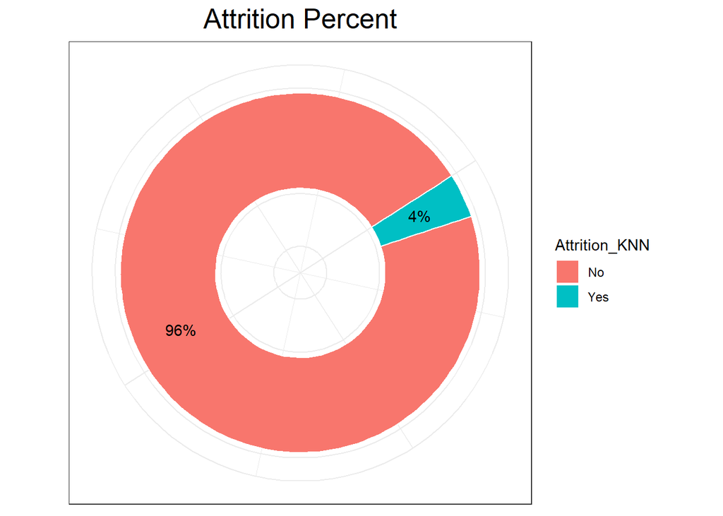

```r
# loading prediction data
attrition_pred_df <- read.csv("https://raw.githubusercontent.com/rajeshsk/DDS-Project-Two/master/Data/CaseStudy2CompSet%20No%20Attrition.csv", sep = ",", header = TRUE)

#read CompSet_NoSalary.csv
#attrition_pred_df = read.csv(file.choose(),header = TRUE, sep = ',')


attrition_pred_df$StockOptionLevel = as.factor(attrition_pred_df$StockOptionLevel)
attrition_pred_df$JobSatisfaction = as.factor(attrition_pred_df$JobSatisfaction)
# generating predictions on test data
attrition_pred_df$Attrition_KNN <- predict(attrition_knn, attrition_pred_df)

attri_predict_percent <- attrition_pred_df%>%group_by(Attrition_KNN) %>% dplyr::summarize(count=n(), Attrition_KNNPercentage = n()/nrow(attrition_pred_df))

ggplot(data=attri_predict_percent,aes(x=2,y=Attrition_KNNPercentage,fill=Attrition_KNN))+
  geom_col(color="white")+
  coord_polar("y",start = 1)+
  geom_text(aes(label=paste0(round(Attrition_KNNPercentage*100),"%")),
            position = position_stack(vjust = 0.5))+
  theme(panel.background = element_blank(),
        axis.line = element_blank(),
        axis.title = element_blank(),
        axis.ticks = element_blank(),
        axis.text = element_blank(),
        plot.title = element_text(hjust = 0.5,size = I(19)))+
  ggtitle("Attrition Percent")+
xlim(.75,2.5)
```

```r
write.csv(attrition_pred_df[c("ID", "Attrition_KNN")], "C:\\Users\\SATRK001\\Case2PredictionsClassify_Attrition_RajeshSatluri.csv")
```

## Conclusion

MaritalStatus can also effect in both ways. Single employees are more likely to leave, while Divorced employees are more likely to stay

Candidates with “Yes” in the OverTime field are more likely to leave.

Suggestions to curb Attrition

Limit Business Travel

Understand How workers feel about Overtime

Consider Remote Work

Consider Hiring people that worked for less number of Companies

Satisfaction Indicators

Work relationships must be maintained